# Geology of the Oceans

Dr. Ahmad Redaa

2025-04-14

# Outlines

- The Topography of the Sea Floor
- The Geology of the Oceanic Crust
- Sea-Floor Sediments
- Ocean Water

# Sea Floor Topography

- Oceans cover ~71% of Earth’s surface and have an average depth of nearly 4,000 metres.
- The sea floor is shaped by plate tectonics and features a wide range of topographic elements.
- It is largely hidden beneath deep waters, making study difficult, but bathymetric surveys have greatly advanced our understanding.

# Major Sea Floor Features

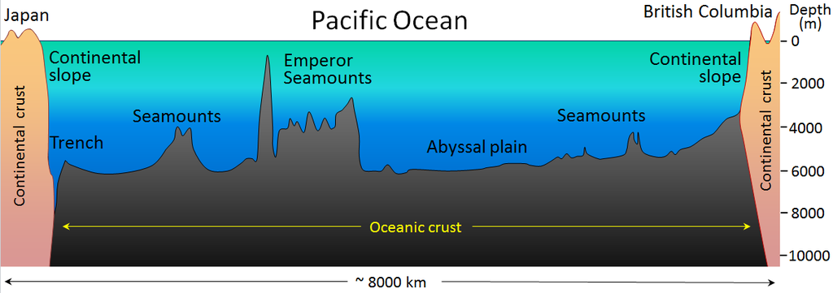

The generalised topography of the Pacific Ocean sea floor between Japan and British Columbia. The vertical exaggeration is approximately 200 times. Source: [Steven, E. (2015)](https://openlibrary-repo.ecampusontario.ca/jspui/handle/123456789/402)

- Continental Shelves
- Continental Slopes
- Abyssal Plains
- Mid-Ocean Ridges
- Seamounts
- Trenches

# Continental Shelves

- Shallow, submerged edges of continents, usually <200 m deep.
- Extend for tens to hundreds of kilometers offshore.
- Rich in marine life—located within the photic zone.
- Examples: Nova Scotia’s shelf is wide; British Columbia’s is narrow due to tectonic activity.

# Continental Slopes

- Mark the transition from continental crust to oceanic crust.
- Slopes descend steeply from shelf edge to abyssal plain—depths increase from ~200 m to several thousand meters.

# Abyssal Plains

- Extremely flat and deep ocean floors (typically 4,000–6,000 m deep).
- Covered with thick layers of fine sediments.
- Represent some of the flattest surfaces on Earth.

# Mid-Ocean Ridges

- Underwater mountain chains formed at divergent plate boundaries.
- Created by seafloor spreading (e.g., Mid-Atlantic Ridge).
- Often shallower than surrounding seafloor (sometimes <3,000 m).

# Seamounts

- Isolated volcanic peaks rising from the ocean floor, not breaking the surface.
- Often formed by hotspot volcanism or near plate boundaries.

# Trenches

- Deep, narrow depressions at subduction zones.
- Among the deepest places on Earth (e.g., Mariana Trench ~11,000 m deep).
- Formed where one tectonic plate is subducted beneath another.

# Depth Zones of the Ocean (Pelagic Zones)

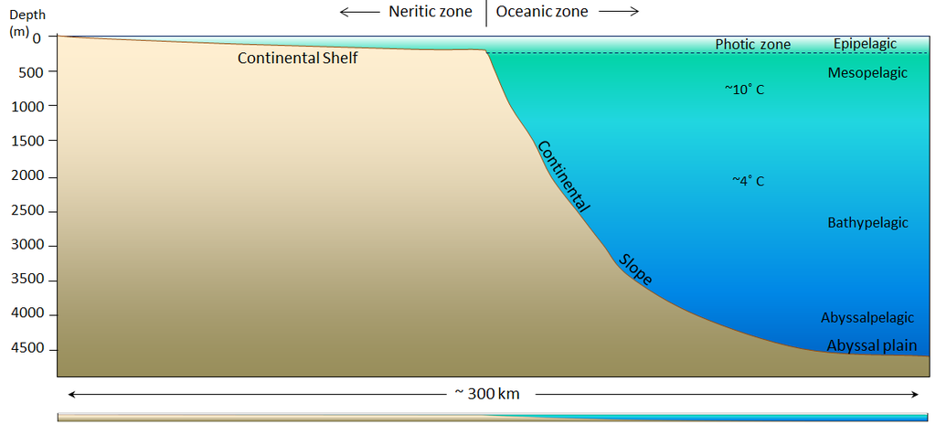

The generalised topography of the Atlantic Ocean floor within 300 kilometres of Nova Scotia. The vertical exaggeration is approximately 25 times. The panel at the bottom shows the same profile without vertical exaggeration. Source: [Steven, E. (2015)](https://openlibrary-repo.ecampusontario.ca/jspui/handle/123456789/402)

| Zone | Depth Range | Description |
| --- | --- | --- |
| Photic Zone | 0 – 200 m | Sunlit layer where photosynthesis occurs; supports most marine life |
| Mesopelagic Zone | 200 – 1,000 m | “Twilight zone” with minimal light; organisms adapt to dim conditions |
| Bathypelagic Zone | 1,000 – 4,000 m | Completely dark; high pressure; home to deep-sea species |
| Abyssopelagic Zone | > 4,000 m | Deepest ocean layer; near or on abyssal plains; very cold and high pressure |

# Subduction Zones and Trench Formation

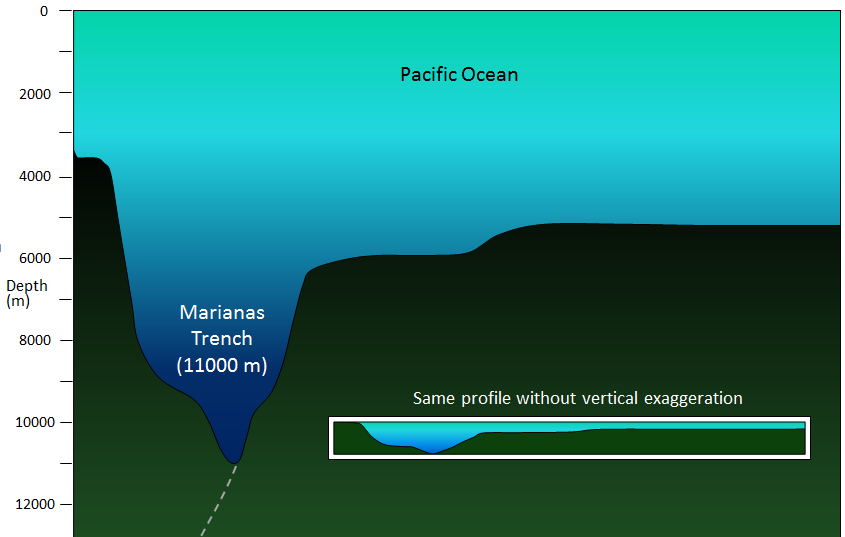

The generalised topography of the Pacific Ocean floor in the area of the Marianas Trench, near Guam. The dashed grey line represents the subduction of the Pacific Plate (to the right) beneath the Philippine Plate (to the left). Source: [Steven, E. (2015)](https://openlibrary-repo.ecampusontario.ca/jspui/handle/123456789/402)

- Trenches form where oceanic crust is forced beneath another plate.
- Sediment fill affects trench visibility—e.g., no visible trench off British Columbia due to Fraser River sediment.
- Marianas Trench: the deepest known ocean trench (11,000 m).
- Other notable trenches: Japan, Peru-Chile, and Puerto Rico Trenches.

# Bathymetric Profiles and Vertical Exaggeration

- Bathymetric profiles often exaggerate vertical scale to highlight features.
- Example: Vertical exaggeration of 200x shows steep slopes and tall ridges that appear more pronounced than they are.
- In reality, abyssal plains are flatter than most land surfaces.

# The Geology of the Oceanic Crust

## Composition and Structure of Oceanic Crust

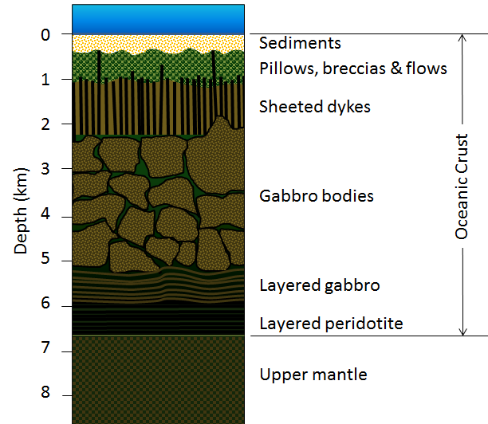

Schematic representation of the lithologic layers of typical oceanic crust (Ophiolite). Source: [Steven, E. (2015)](https://openlibrary-repo.ecampusontario.ca/jspui/handle/123456789/402)

| **Layer** | **Approximate Depth** | **Composition** |
| --- | --- | --- |
| Ocean floor sediments | 0 – 0.5 km | Limestone, mudstone, chert, turbidites |
| Volcanic layer | 0.5 – 1.0 km | Pillow basalts, breccias, basaltic flows |
| Sheeted dykes | 1.0 – 2.0 km | Vertical conduits feeding the lavas |
| Gabbro bodies | 2.0 – 5.0 km | Coarse-grained mafic intrusive rock |
| Layered gabbro | 5.0 – 6.0 km | Crystallized mafic intrusions |
| Layered peridotite | 6.0 – 6.5 km | Ultramafic rocks from the lower crust |
| Upper mantle | > 6.5 km | Peridotite |

# Formation Process at Mid-Ocean Ridges

- Oceanic crust forms at **divergent plate boundaries**—specifically, at **mid-ocean ridges**.
- **Decompression melting** of rising hot mantle rock generates mafic magma.
- The magma forms:
  - **Pillow basalts** at the surface
  - **Sheeted dykes** that feed the lava
  - **Gabbros and ultramafic rocks** in deeper layers
- Over time, these layers are buried under **marine sediments**.

# Age of Oceanic Crust and Magnetic Anomalies

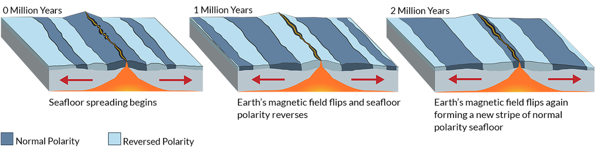

Magnetics Polarity of the seafloor. Source: [https://divediscover.whoi.edu](https://divediscover.whoi.edu/mid-ocean-ridges/magnetics-polarity/)

- Oceanic crust is geologically young:
  - Most is less than **100 million years old**
  - The oldest known oceanic crust is **~280 Ma**
- Magnetic stripes on the seafloor record **Earth’s magnetic reversals**:
  - Symmetrical patterns on either side of ridges help determine crust age
  - Faster spreading ridges show wider age bands (e.g., East Pacific Rise)
  - Slower ridges show narrower bands (e.g., Mid-Atlantic Ridge)

# Seamounts and Hotspot Volcanism

- **Seamounts** are underwater volcanoes, many of which do not reach the ocean surface.
- Formed by:
  - **Hotspots**: Stationary plumes of magma (e.g., Hawaii, Galapagos)
    - Older volcanoes move away from the hotspot and subside
    - Example: Hawaiian–Emperor Chain
  - **Subduction zones**: Create volcanic arcs like the Aleutians and Lesser Antilles
- Not all seamount chains show a clear age progression (e.g., Line Islands formed by rifting)

# Hotspots

[figure not shown]

Model of a mantle plume and hot-spot volcanism producing island chains (Tasa Graphics 2010). Source: [https://exploringtheearth.com](https://exploringtheearth.com/2013/05/25/galapagos_islands/mantle_plume_model/)

# Subduction Zone

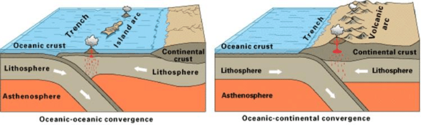

Example of a Subduction zone; left: intra-oceanic subduction and formation of an island arc; right: underthrusting of an oceanic plate beneath continental tectonic plate and formation of a volcanic arc (USGS). Source: [Sanclemente (2014)](https://www.researchgate.net/figure/Example-of-a-Subduction-zone-left-intra-oceanic-subduction-and-formation-of-an-island_fig2_263734347)

# Formation of Reefs and Atolls

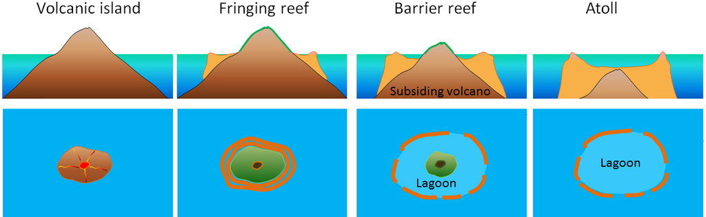

The formation of a fringing reef, a barrier reef, and an atoll around a subsiding tropical volcanic island. Source: [Steven, E. (2015)](https://openlibrary-repo.ecampusontario.ca/jspui/handle/123456789/402)

- Coral reefs often form around tropical volcanic islands:
  - **Fringing reef** develops around an active island
  - **Barrier reef** forms as the island subsides and a lagoon develops
  - **Atoll** results when the volcanic island is fully submerged, but the reef remains
- These features are controlled by:
  - **Sea-level rise** (e.g., post-glacial)
  - **Volcanic subsidence**
- If subsidence is **slow**, the reef can keep up with sea level and remain near the surface

# Sea-Floor Sediments

## Types of Sea-Floor Sediment

- **Terrigenous Sediment**
- **Pelagic Carbonate Sediment**
- **Pelagic Silica Sediment**
- **Volcanic Material**
- **Iron-Manganese Nodules**

# Terrigenous Sediment

- **Origin:** Weathering and erosion of continental rocks
- **Transported by:** Rivers, glaciers, wind, ocean currents
- **Composition:** Quartz, feldspar, clay minerals, iron oxides, organic matter
- **Location:** Near continental margins, in inland seas and large lakes
- **Grain size:** Coarse nearshore (sand, silt); clay-sized particles transported further offshore

# Pelagic Carbonate Sediment

- **Origin:** Microscopic marine organisms (e.g., foraminifera) that build shells of **calcite**
- **Depositional zones:** Shallow to mid-depth ocean regions with high biological productivity
- **Form:** Carbonate ooze, which lithifies over time into limestone
- **Limit:** Dissolves below the **carbonate compensation depth (CCD)**

# Pelagic Silica Sediment

- **Origin:** Silica-secreting marine organisms (e.g., diatoms, radiolaria)
- **Depositional zones:** Equatorial Pacific, southern ocean regions, and beneath high productivity zones
- **Form:** Siliceous ooze, lithifies into chert

# Volcanic Material

- **Origin:** Submarine and terrestrial eruptions
- **Types:** Volcanic ash, pyroclastic fragments, lava
- **Location:** Near volcanic arcs and oceanic hotspots

# **Iron-Manganese Nodules**

- **Origin:** Direct chemical precipitation from seawater
- **Composition:** Concentric layers of manganese and iron oxides
- **Location:** Deep ocean basins, away from rapid sediment accumulation
- **Notes:** Nodules grow very slowly over millions of years

# What type of sediment?

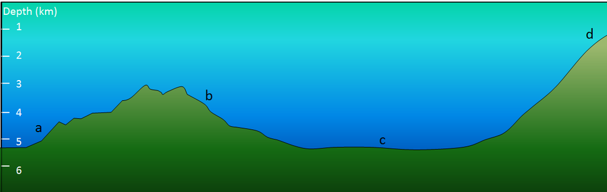

The diagram shows the sea floor in an area where there is abundant pelagic carbonate sediment. There is a continent within 100 kilometres of this area, to the right. What type of sediment (coarse terrigenous, clay, siliceous ooze, or carbonate ooze) would you expect at find at locations a, b, c, and d? Source: [Steven, E. (2015)](https://openlibrary-repo.ecampusontario.ca/jspui/handle/123456789/402)

Answer: a. Siliceous ooze or clay b. Carbonate ooze c. Siliceous ooze or clay d. Coarse terrigenous or carbonate ooze

# Sediment Distribution Patterns

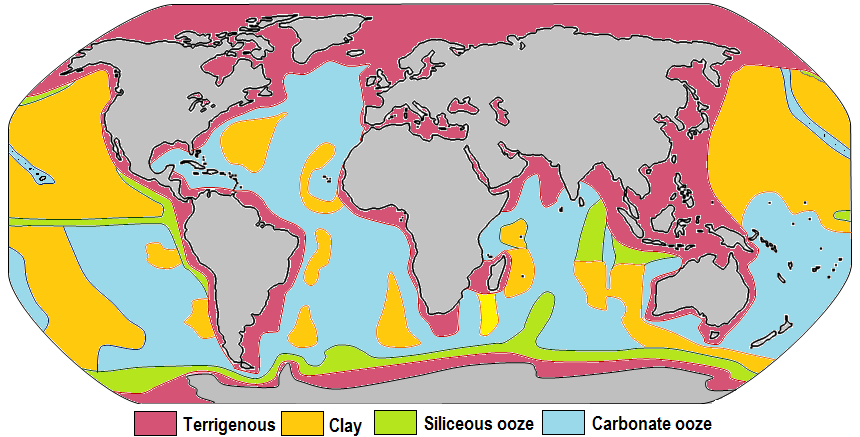

The distribution of sediment types on the sea floor. Within each coloured area, the type of material shown is what dominates, although other materials are also likely to be present. Source: [Steven, E. (2015)](https://openlibrary-repo.ecampusontario.ca/jspui/handle/123456789/402)

- **Near continents:** Coarse terrigenous sediments dominate
- **Open oceans:** Fine-grained **clay**, **carbonate ooze**, and **siliceous ooze** predominate
- **Equatorial and mid-latitude regions:** High carbonate productivity (carbonate oozes)
- **Polar and equatorial upwelling zones:** High silica productivity (siliceous oozes)
- **Deep basins (>4000 m):** Dominated by **clay** and **silica**, as carbonate dissolves below the CCD

# Carbonate Compensation Depth (CCD)

- **Definition:** The depth at which the rate of carbonate dissolution equals its supply
- **Typical depth:** Around **4,000 metres**, but varies with temperature and pressure
- **Above CCD:** Carbonate accumulates
- **Below CCD:** Carbonate dissolves; no carbonate ooze forms
- **Result:** Carbonate sediments are restricted to shallower parts of ocean basins (e.g., mid-ocean ridges, seamount tops)

# Methane Hydrates

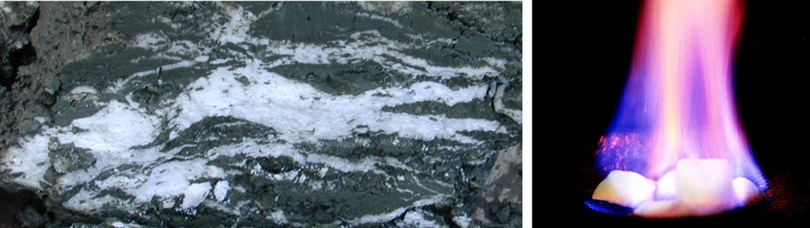

Left: Methane hydrate within muddy sea-floor sediment from an area offshore from Oregon. Right: Methane hydrate on fire. Source: [Steven, E. (2015)](https://openlibrary-repo.ecampusontario.ca/jspui/handle/123456789/402)

## What Are Methane Hydrates?

- **Methane hydrate**, also called **methane clathrate**, is a crystalline solid in which **methane (CH₄)** gas molecules are trapped within cages of **water molecules**, forming a structure similar to ice. It is stable under **low temperature** and **moderate to high pressure** conditions, typically found in:
  - Marine sediments on **continental slopes** (500–1,000 m depth)
  - **Permafrost** regions in the Arctic
- Methane hydrate looks like ice but **releases flammable methane gas** when warmed or depressurized.

## Formation

- Produced by **anaerobic decomposition** of organic matter in sediments
- Methane (CH₄) combines with water at low temperatures and moderate pressures to form **methane hydrate**

## Location

- Found on **continental slopes** at depths of **500 to 1,000 m**
- Stable under conditions of low temperature (~4°C) and high pressure

## Climate Implications

- Represents a massive reservoir of **fossil carbon**
- Potential as an **energy resource**
- Concern: **Methane is a potent greenhouse gas**
  - Release could exacerbate **climate change**
  - Past methane releases have been linked to abrupt **paleoclimate events**

# Ocean Water

## Composition and Salinity of Seawater

Seawater is salty because it contains **dissolved ions** derived from **weathering of continental rocks** and **hydrothermal processes at mid-ocean ridges**.

# Major Dissolved Ions in Seawater (by weight)

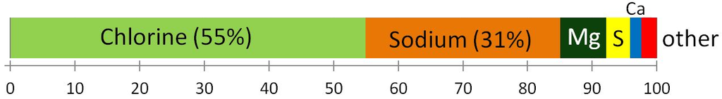

The proportions (by weight) of the major dissolved elements in ocean water. Source: [Steven, E. (2015)](https://openlibrary-repo.ecampusontario.ca/jspui/handle/123456789/402)

| **Ion** | **Source** |
| --- | --- |
| Chloride (Cl⁻) | Weathering of rocks, volcanic gases |
| Sodium (Na⁺) | Weathering of feldspars and other silicates |
| Sulfate (SO₄²⁻) | Volcanic gases, oxidation of sulfides |
| Magnesium (Mg²⁺) | Crustal weathering |
| Calcium (Ca²⁺) | Used biologically (e.g., for carbonate shells) |
| Potassium (K⁺) | Weathering of feldspars and micas |

- The **average salinity** of ocean water is **35 g/L**, or 3.5%.
- Most of the salt is **sodium chloride (NaCl)**, but seawater also contains **magnesium, sulfate, calcium**, and **trace elements**.

# Salinity Variation and Causes

- Salinity is **not uniform** and varies with:
  - **Evaporation** (increases salinity)
  - **River inflow / precipitation** (decreases salinity)
  - **Sea ice formation** (increases salinity of surrounding water)
  - **Sea ice melting** (lowers salinity)

## Salinity Patterns:

- **Lowest salinity**: Arctic Ocean and near river mouths (e.g., Amazon, Ganges)
- **Highest salinity**: Semi-enclosed seas in hot dry climates (e.g., **Red Sea**, **Mediterranean Sea**)

Despite large river inputs into the Mediterranean, **evaporation exceeds inflow**, so **Atlantic water flows into** the Mediterranean through the **Strait of Gibraltar**.

# Sea-Surface Temperature Distributions

Ocean temperatures vary with **latitude** and **depth**.

| **Location** | **Average Surface Temperature** |
| --- | --- |
| Equator | 25°C to 30°C |
| Mid-latitudes (e.g., Canada) | 5°C to 15°C |
| Polar regions | ~0°C (can go down to -2°C due to salt) |

- Warmest waters are found in the **tropics**, coldest at the **poles**
- Currents like the **Gulf Stream** redistribute heat from equator to higher latitudes

# Ocean Currents

Ocean currents are critical for **heat redistribution** and **climate regulation**.

# Surface Currents

- **Driven by wind** and influenced by **Earth’s rotation (Coriolis effect)**:
  - Currents deflect **clockwise in the Northern Hemisphere**
  - **Counterclockwise in the Southern Hemisphere**
- These large-scale current systems are called **gyres**.

## Examples:

- **Gulf Stream**: Warm current flowing from the tropics to the North Atlantic
- **California Current**: Cold current flowing south along the U.S. west coast
- **Labrador Current**: Cold current bringing icebergs past Newfoundland

# Deep-Ocean Circulation (Thermohaline Circulation)

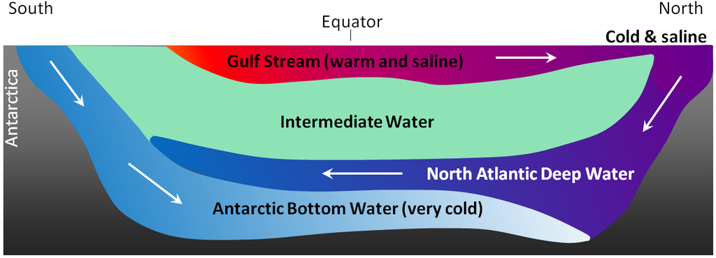

A depiction of the vertical movement of water along a north-south cross-section through the Atlantic basin. Source: [Steven, E. (2015)](https://openlibrary-repo.ecampusontario.ca/jspui/handle/123456789/402)

- Driven by **differences in water density**, which depends on **temperature** and **salinity**
- Referred to as the **Global Ocean Conveyor Belt**

## Key Components:

- **North Atlantic Deep Water (NADW)**: Forms as salty Gulf Stream water cools and sinks in the North Atlantic
- **Antarctic Bottom Water (AABW)**: Very cold, dense water formed around Antarctica that sinks and flows northward beneath NADW

# Importance of Ocean Circulation to Global Climate

- Transports **heat** from equator to poles
- Distributes **nutrients and gases** through the ocean
- Regulates **regional climates**:
  - Western Europe is warmer than eastern Canada at similar latitudes due to the **Gulf Stream**
- Disruptions to thermohaline circulation can cause **rapid climate shifts**, as evidenced during the **Pleistocene glaciations**